# FlaringABM input leases

Nick Willems

GENERATE SAMPLE OIL AND GAS WELLS & LEASES FROM TEXAS RAILROAD COMMISSION DATA

EACH WELL HAS THE FOLLOWING PROPERTIES  
1. DEPTH  
2. LOCATION  
- Lat & Lon  
- Area  
3. COMPLETION DATE

EACH LEASE HAS THE FOLLOWING PROPERTIES  
1. AVERAGE MONTHLY OIL PRODUCTION OVER THE STUDY PERIOD  
- Marketable production (`oil_avg`)  
- Total production (`total_oil_avg`)  
2. AVERAGE MONTHLY GAS PRODUCTION OVER THE STUDY PERIOD  
- Marketable production (`gas_avg`, `csgd_avg`)  
- Total production of gas or casinghead gas (`total_MCF_avg`)  
- Flared gas or casinghead gas (`flared_MCF_avg`)  
3. LOCATION  
- Lat & Lon  
- Area  
4. DISTANCE FROM INFRASTRUCTURE  
- Crude pipelines  
- Gas processing facilities

Well data is used to find approximate lease locations and to calculate capital expenditures based on well depth(s). Cost parameters are derived during initialization by matching leases to areas and sampling data from: [US EIA. (2016)](https://www.eia.gov/analysis/studies/drilling/).

```r
library(readxl)
library(data.table)
library(sf)
library(maps)
```

## Production Data Query Dump

[Source](https://mft.rrc.texas.gov/link/fe3298a2-8788-4234-b2a0-90ee41558d75), [Manual](https://www.rrc.texas.gov/media/50ypu2cg/pdq-dump-user-manual.pdf)

> This is a complete dump of the Production Data and Historical Ledger databases and includes production from 1993 to current. The file is updated once monthly and is delivered via cloud service.

# Import spatial data

[Source: Play boundaries](https://www.eia.gov/maps/maps.htm), [Source: Processing plants & crude pipelines](https://www.eia.gov/maps/layer_info-m.php)

```r
TX <- st_as_sf(map("state", regions="Texas", plot=FALSE, fill=TRUE))
names(TX)[names(TX)=="geom"] <- "geometry"
st_geometry(TX) <- "geometry"
head(TX)
```

```
## Simple feature collection with 1 feature and 6 fields
## geometry type:  POLYGON
## dimension:      XY
## bbox:           xmin: -106.6462 ymin: 25.83722 xmax: -93.50781 ymax: 36.50039
## geographic CRS: WGS 84
##   FID FIPS CREATE_USE CMNT SHAPE_Leng SHAPE_Area                       geometry
## 1   1   48        TPP <NA>   56.83538   65.72923 POLYGON ((-100.5002 36.4998...
```

```r
plot(TX$geometry, reset=FALSE, main="Gas plants and crude oil pipelines in Texas")

permian     <- st_read("./data/spatial/PermianBasin_Boundary_Structural_Tectonic",
                        layer="Permian_SubBasins_201712", quiet=TRUE)
head(permian)
```

```
## Simple feature collection with 5 features and 5 fields
## geometry type:  POLYGON
## dimension:      XY
## bbox:           xmin: -104.8481 ymin: 29.46306 xmax: -100.0366 ymax: 33.55119
## geographic CRS: WGS 84
##                     Name Area_sq_km Area_sq_mi Shape_Leng Shape_Area
## 1 Central Basin Platform  16112.605   6221.111   5.784618  1.5345904
## 2         Delaware Basin  31149.189  12026.769   6.626074  2.9649241
## 3          Midland Basin  32635.787  12600.748  11.352882  3.1217446
## 4             Ozona Arch   3580.109   1382.288   2.290080  0.3380149
## 5        Val Verde Basin  18010.435   6953.868   6.016117  1.6876163
##                         geometry
## 1 POLYGON ((-103.1445 32.7727...
## 2 POLYGON ((-102.8807 31.1482...
## 3 POLYGON ((-102.7472 32.8391...
## 4 POLYGON ((-101.8652 31.2421...
## 5 POLYGON ((-101.185 30.73155...
```

```r
spraberry   <- st_read("./data/spatial/ShalePlays_AboYeso_GlorietaYeso_Spraberry_EIA",
                        layer="ShalePlay_Spraberry_Boundary_EIA_Aug2015_v2", quiet=TRUE)
head(spraberry)
```

```
## Simple feature collection with 1 feature and 7 fields
## geometry type:  POLYGON
## dimension:      XY
## bbox:           xmin: -102.3659 ymin: 31.06312 xmax: -101.0197 ymax: 33.08302
## geographic CRS: WGS 84
##     Basin                                   Lithology Shale_play Source
## 1 Permian Mixed Shale & Limestone-Siltstone-Sandstone  Spraberry    EIA
##   Area_sq_mi Area_sq_km Age_shale                       geometry
## 1       5297      13719   Permian POLYGON ((-101.4078 33.0183...
```

```r
eagle_ford  <- st_read("./data/spatial/EagleFord_Play_Boundary_Elevation_Isopach_EIA",
                        layer="ShalePlay_EagleFord_Boundary_EIA_Aug2015_v2", quiet=TRUE)
head(eagle_ford)
```

```
## Simple feature collection with 1 feature and 7 fields
## geometry type:  POLYGON
## dimension:      XY
## bbox:           xmin: -100.5805 ymin: 27.48908 xmax: -96.51267 ymax: 30.30348
## geographic CRS: WGS 84
##          Basin Lithology Shale_play Source Area_sq_mi Area_sq_km  Age_shale
## 1 Western Gulf     Shale Eagle Ford    EIA      14644      37929 Cretaceous
##                         geometry
## 1 POLYGON ((-100.5614 28.8291...
```

```r
# merge permian and eagle_ford shapefiles
TX <- st_transform(TX, st_crs(permian))
cat("CRS ok:", (st_crs(permian) == st_crs(TX)), "\n")
```

```
## CRS ok: TRUE
```

```r
cat("CRS ok:", (st_crs(permian) == st_crs(spraberry)) & (st_crs(permian) == st_crs(eagle_ford)), "\n")
```

```
## CRS ok: TRUE
```

```r
permian$geometry <- st_difference(permian$geometry, spraberry$geometry)
```

```
## although coordinates are longitude/latitude, st_difference assumes that they are planar
```

```r
areas <- rbind(cbind("Name"="Eagle Ford", eagle_ford[, c("Area_sq_mi", "Area_sq_km")]),
                cbind("Name"="Spraberry", spraberry[, c("Area_sq_mi", "Area_sq_km")]),
                permian[permian$Name %in% c("Delaware Basin", "Midland Basin"), c("Name", "Area_sq_mi", "Area_sq_km")])

plot(areas$geometry, col=rainbow(4, alpha=0.5), add=TRUE)
legend('bottomleft', areas$Name, fill=rainbow(4, alpha=0.5))

# gas processing plants
gas_plants <- st_read("./data/spatial/NaturalGas_ProcessingPlants_US_EIA",
                        layer="NaturalGas_ProcessingPlants_US_2017_v2", quiet=TRUE)
head(gas_plants)
```

```
## Simple feature collection with 6 features and 16 fields
## geometry type:  POINT
## dimension:      XY
## bbox:           xmin: -111.9598 ymin: 31.29948 xmax: -95.51805 ymax: 48.73838
## geographic CRS: WGS 84
##                      Plant_Name                                      Owner
## 1 50 Buttes Processing Facility          Thunder Creek Gas Services,L.L.C.
## 2                    Ajax Plant Enbridge Pipelines (Texas Gathering), L.P.
## 3                         Alamo                   La Grange Acquisition LP
## 4             Allison Gas Plant  Enbridge Pipelines (Texas Gathering) L.P.
## 5                 Aloe Ventures                               Lamarsa Corp
## 6            Altamont Gas Plant                              Kinder Morgan
##                                    Operator     City State   County    ZipCode
## 1        Thunder Creek Gas Services, L.L.C. Gillette    WY Campbell      82718
## 2 Enbridge Pipelines (Texas Gathering) L.P.  Wheeler    TX  Wheeler      79096
```

[output cut: 18 more lines]

```r
plot(gas_plants$geometry, col="orange", pch="+", cex=1.5, add=TRUE)

# crude oil pipelines
crude_pipelines <- st_read("./data/spatial/CrudeOil_Pipelines_US_EIA",
                            layer="CrudeOil_Pipelines_US_202001", quiet=TRUE)
head(crude_pipelines)
```

```
## Simple feature collection with 6 features and 3 fields
## geometry type:  MULTILINESTRING
## dimension:      XY
## bbox:           xmin: -101.2513 ymin: 38.7553 xmax: -78.78838 ymax: 49.75523
## geographic CRS: WGS 84
##   Opername    Pipename Shape_Leng                       geometry
## 1 ENBRIDGE LSr Project   6.336283 MULTILINESTRING ((-95.38768...
## 2 ENBRIDGE     Buffalo   1.184984 MULTILINESTRING ((-78.78838...
## 3 ENBRIDGE      Chicap   3.044770 MULTILINESTRING ((-89.0953 ...
## 4 ENBRIDGE    Lakehead   6.127059 MULTILINESTRING ((-97.53267...
## 5 ENBRIDGE    Lakehead   7.326726 MULTILINESTRING ((-92.06769...
## 6 ENBRIDGE    Lakehead   7.354465 MULTILINESTRING ((-92.06769...
```

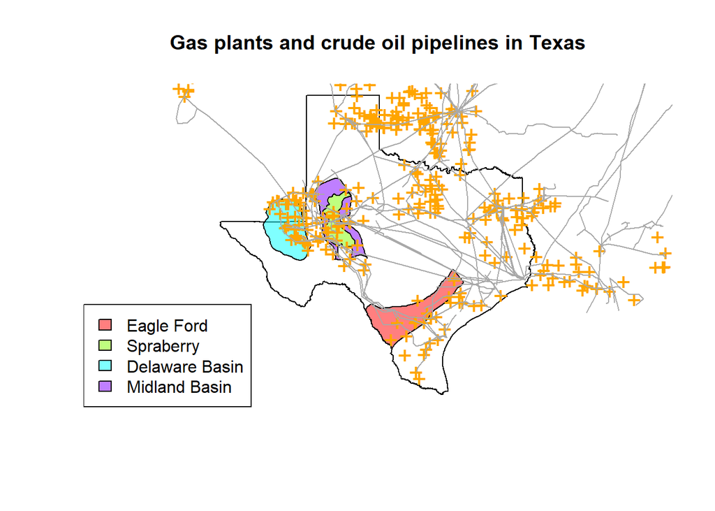

```r
plot(crude_pipelines$geometry, col="darkgrey", add=TRUE)
```

```r
# store list of shapefiles
cat("CRS ok:", (st_crs(permian) == st_crs(crude_pipelines)) & (st_crs(permian) == st_crs(gas_plants)), "\n")
```

```
## CRS ok: TRUE
```

```r
spatial_data <- list("state"=TX, "areas"= areas,
                    "gas_plants"= gas_plants[gas_plants$State %in% c("LA","NM","OK","TX"),],
                    "crude_pipelines"= crude_pipelines)

rm(TX, permian, spraberry, eagle_ford, areas, gas_plants, crude_pipelines)
```

# Process Wellbores

Identify locations, depths, and completion date of wellbores to subsequently merge into the lease production data

## Wellbore Completion data

Contains lease numbers (PDQ)

```r
OG_WELL <- fread("unzip -p ./data/PDQ_DSV.zip OG_WELL_COMPLETION_DATA_TABLE.dsv", sep="}",
                select=list(character=c("COUNTY_NAME", "OIL_GAS_CODE", "DISTRICT_NO", "LEASE_NO",
                            "API_COUNTY_CODE", "API_UNIQUE_NO", "WELL_NO")))
OG_WELL[, "API_NO":= paste0(API_COUNTY_CODE, API_UNIQUE_NO)]
```

## Full Wellbore

Contains lat/lon & depth [Source](https://mft.rrc.texas.gov/link/9ef1955f-cf26-4bd4-8030-1253eb772cf9), [Manual](https://www.rrc.texas.gov/media/cx2i4xrm/wba091_well-bore-database.pdf)

```r
wellbore_full <- fread("./data/dbf900.txt.gz", sep="\n", header=FALSE)

# find unique wellbores (including API number) and assign parent record id
wellbore_full[, "id":= nafill(ifelse(grepl("^01", V1), .I, NA), type="locf")]
```

Find location information

```r
unique_locs <- wellbore_full[, grep("^13", V1)]
cat(wellbore_full[, 100 * uniqueN(id[unique_locs]) / uniqueN(id)], "% of 'full' wellbores have lat/lon data\n")
```

```
## 83.43812 % of 'full' wellbores have lat/lon data
```

```r
unique_bors <- wellbore_full[unique_locs, id]
```

In the single case where there is a duplicate, the first location is the correct one (based on [searching](http://webapps2.rrc.texas.gov/EWA/wellboreQueryAction.do) the well by API and cross checking the county number with lat/lon data)

```r
cat(sum(duplicated(unique_bors)), "duplicate location record(s).",
    "Including id(s):", unique_bors[duplicated(unique_bors)],"\n")
```

```
## 1 duplicate location record(s). Including id(s): 16354902
```

```r
unique_locs <- unique_locs[!duplicated(unique_bors)]
unique_bors <- unique_bors[!duplicated(unique_bors)]
```

Extract relevant wellbore data from hierarchical records

```r
wellbore_data <- wellbore_full[sort(c(unique_bors, unique_locs)),
                                # API number, depth, and completion date from record 01
                                .("API_NO"= substr(V1[1], 3, 10), "depth"= substr(V1[1], 29, 33),
                                "start"= substr(V1[1], 21, 26),
                                # location lat/lon from record 13
                                "lat"= substr(V1[2], 133, 141), "lon"= substr(V1[2], 143, 151)), by=id]

wellbore_data[, "lat":=  as.numeric(gsub("(\\d{3})(\\d{6})", "\\1.\\2", lat))]
wellbore_data[, "lon":= -as.numeric(gsub("(\\d{3})(\\d{6})", "\\1.\\2", lon))]
wellbore_data[, "depth":= as.numeric(depth)]
wellbore_data[, "start":= as.numeric(start)]
wellbore_data[start<150000, "start":= NA_integer_]
```

Get missing start dates from WB-DATE segment

```r
wellbore_data[
    wellbore_full[wellbore_data[is.na(start)], on="id"][
        grepl("^03", V1), .(as.numeric(substring(V1, c(40,48), c(45,53)))), by=id][V1>0, min(V1), by=id],
    on="id", "start":= V1]
```

Well depth information in WB-OVERRIDE-BONDED-DEPTH, WB-TOTAL-BONDED-DEPTH

```r
# NOT RUN
wellbore_data[wellbore_full[unique_bors][nchar(V1)>=157], on="id",
            "depth":= if (depth==0) as.numeric(substring(V1, 152, 157)), by=.EACHI]
wellbore_data[wellbore_full[unique_bors], on="id",
            "depth":= if (depth==0) as.numeric(substring(V1, 133, 138)), by=.EACHI]
```

Well depth from formation segement WB-FORMATION-DEPTH

```r
# NOT RUN
unique_form <- wellbore_full[, .I[(nchar(V1)>=42) & (id %in% wellbore_data[depth==0]$id) & grepl("^09", V1)]]
wellbore_data[wellbore_full[unique_form, max(as.numeric(substring(V1, 38, 42))), by=id], on="id", "depth":= V1]
```

## Permit

Contains well type & depth [Source](https://mft.rrc.texas.gov/link/91a36fea-4dad-4f26-96c3-30843d0e0315), [Manual](https://www.rrc.texas.gov/media/ezxjqdmn/oga049.pdf)

```r
well_permits <- fread("./data/daf804.txt.gz", sep="\n", header=FALSE)

# identify unique entries
well_permits[, "ID":= .I]
well_permits[, "sequence_no":= substr(V1, 10, 11), by=ID]
well_permits[, "API_NO":= substr(V1, 503, 510), by=ID]

# is this a horizontal well?
# well_permits[, "horizontal":= any(substring(V1, c(482, 494), c(482, 494)) == "Y"), by=ID]
well_permits[, "horizontal":= (substr(V1, 482, 482) == "Y"), by=ID]
well_permits[, "horizontal":= horizontal[which.min(sequence_no)], by=API_NO]

wellbore_data[well_permits[horizontal==TRUE, .("API_NO"=unique(API_NO))], on="API_NO", "horizontal":= TRUE]
wellbore_data[is.na(horizontal), "horizontal":= FALSE]

# get missing well depths
well_permits[, "depth":= as.numeric(substr(V1, 55, 59)), by=ID]
wellbore_data[well_permits[depth>0, depth[which.min(sequence_no)], by=API_NO], on="API_NO",
            "depth":= if (depth==0) V1, by=.EACHI]
rm(well_permits)
```

Drop suspicious locations, outlier depths, and wells drilled outside of study period relevance

```r
wellbore_data[lat==0 | lon==0, c("lat","lon"):= NA]
wellbore_data[depth==0 | !(depth %between% quantile(depth[depth>0], c(0.01, 0.99))), "depth":= NA]
wellbore_data[!between(start, 196301, 201909), c("lat","lon","depth"):= NA]
```

Estimate completion cost based on wellbore depth in meters (Lukawski et al. 2014)

```r
# NOT RUN
wellbore_data[, "DC_cost":= (1.65e-5)*(depth/3.28084)^1.607]
```

Merge locations & depth information into full well record

```r
OG_WELL[wellbore_data, on="API_NO", c("start","lat","lon","depth","horizontal"):= .(start, lat, lon, depth, horizontal)]

cat("Matched", OG_WELL[, 100*sum(!is.na(lat))/.N], "% of wells with lat/lon positions\n")
```

```
## Matched 91.06972 % of wells with lat/lon positions
```

```r
cat("Matched", OG_WELL[, 100*sum(!is.na(depth))/.N], "% of wells with depths\n")
```

```
## Matched 80.8597 % of wells with depths
```

```r
rm(wellbore_full)
rm(wellbore_data)
```

## Map wells to areas

```r
OG_WELL[!is.na(lat), "area":= st_join(st_as_sf(.SD, coords=c("lon","lat"), crs=st_crs(spatial_data$area)),
                                        spatial_data$area, join=st_within)$Name]
```

```
## although coordinates are longitude/latitude, st_within assumes that they are planar
```

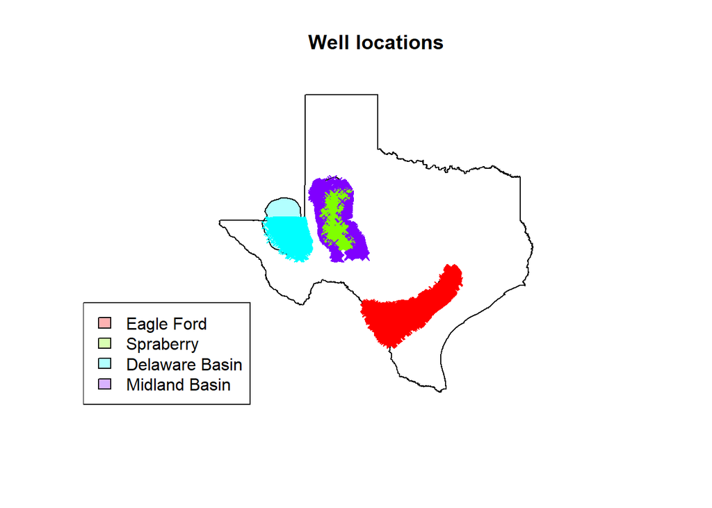

```r
# remove duplicate entries
OG_WELL[OG_WELL[, duplicated(.SD[, -"WELL_NO"])], "area":= NA]

plot(spatial_data$state$geometry, reset=FALSE, main="Well locations")
plot(spatial_data$areas$geometry, col=rainbow(4, alpha=0.3), add=TRUE)
legend("bottomleft", spatial_data$areas$Name, fill=rainbow(4, alpha=0.3))
OG_WELL[!is.na(area) & !is.na(depth), plot(st_as_sf(.SD, coords=c("lon","lat"), crs=st_crs(spatial_data$area))$geometry,
                                        col=rainbow(4)[factor(area, levels=spatial_data$areas$Name)], pch=4, add=TRUE)]
```

## Check for multilateral wells and multi-well pads

Multilaterals with completion dates less than a year apart

```r
OG_WELL[!is.na(area),
        "stacked":= if((uniqueN(API_NO) > 1) & (max(start)-min(start) <= 100)) API_NO[which.min(start)],
        by=.(lat, lon, OIL_GAS_CODE)]
OG_WELL[!is.na(area) & is.na(stacked),
        "stacked":= if((uniqueN(API_NO) > 1) & (max(start)-min(start) <= 100)) API_NO[which.min(start)],
        by=.(round(lat, 5), round(lon, 5), OIL_GAS_CODE)]
OG_WELL[!is.na(area) & is.na(stacked),
        "stacked":= if((uniqueN(API_NO) > 1) & (max(start)-min(start) <= 100)) API_NO[which.min(start)],
        by=.(trunc(lat*10^5)/10^5, trunc(lon*10^5)/10^5, OIL_GAS_CODE)]
cat("Identified",  OG_WELL[, 100 * sum(!is.na(stacked)) / .N], "% of wells which are actually stacked multilaterals")
```

```
## Identified 0.05750743 % of wells which are actually stacked multilaterals
```

Identify wells which are close enough together to share a wellpad [~1320 ft](https://www.eia.gov/analysis/studies/drilling/)

```r
OG_WELL[!is.na(area) & !duplicated(API_NO),
        # find clusters, approximating distance by treating earth as a sphere with radius 40,075 km
        "shared":= cutree(hclust(dist((40075/360)*.SD[, .(lat, lon*cos(lat*pi/180))]),
                            method="complete"), h=1320/3.281/1000),
        by=.(area, DISTRICT_NO)]

OG_WELL[OG_WELL[!is.na(shared), .N, by=.(shared, area, DISTRICT_NO)],
            on=c("shared", "area", "DISTRICT_NO"), "shared":= N]
OG_WELL[is.na(shared), "shared":= 1]
```

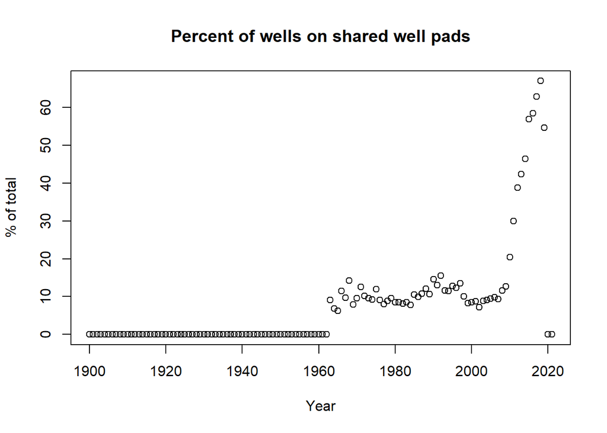

```r
OG_WELL[!duplicated(API_NO), 100 * sum(shared>1, na.rm=TRUE) / .N, by=.("year"=as.numeric(substr(start, 1, 4)))][,
        {plot(year, V1, main="Percent of wells on shared well pads", xlab="Year", ylab="% of total"); NULL}]
```

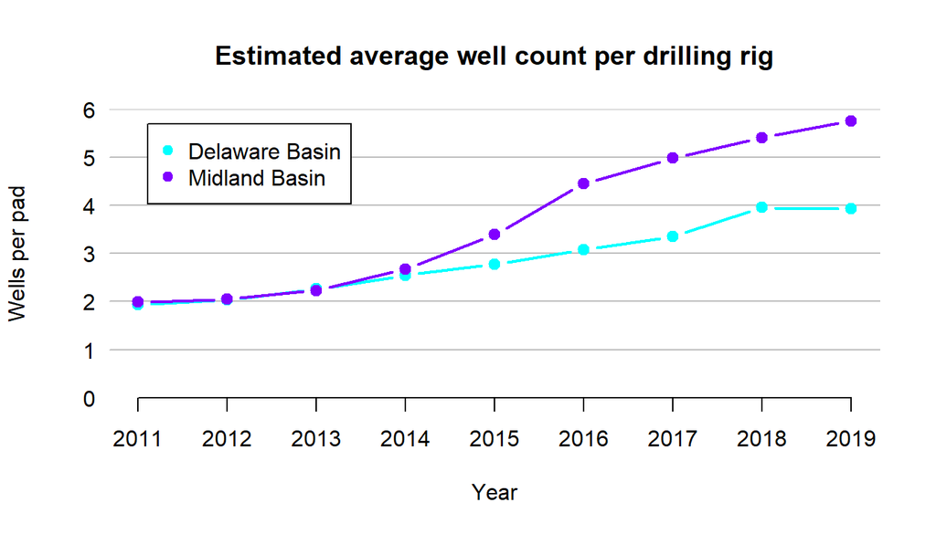

[figure not shown]

```r
OG_WELL[!duplicated(API_NO) & (area %in% c("Midland Basin", "Spraberry", "Delaware Basin")),
        .(mean(shared[area=="Delaware Basin"]), mean(shared[area %in% c("Midland Basin", "Spraberry")])),
        keyby=.("year"= as.numeric(substr(start, 1, 4)))][between(year, 2011, 2020),
        {plot(0, 0, xlim=c(2011,2019), ylim=c(0,6), yaxt='n', yaxs='i', lab=c(9,7,7), bty='n',
            main="Estimated average well count per drilling rig", xlab="Year", ylab="Wells per pad");
        axis(2, tick=FALSE, las=2, hadj=0); abline(h=1:6, col="grey");
        matplot(year, .SD[,-1], type='b', col=rainbow(4)[3:4], pch=19, lty=1, lwd=2, add=TRUE);
        legend("topleft", inset=0.05, legend=c("Delaware Basin", "Midland Basin"), col=rainbow(4)[3:4], pch=19); NULL}]
```

[EIA plot based on Enverusa data](https://www.eia.gov/todayinenergy/detail.php?id=50016)

# Lease data

## Historical Disposition by Lease

Includes (flared) gas volumes (PDQ) [TxRRC](http://webapps2.rrc.texas.gov/EWA/help/prod_results_questions.html):

> “Disposition details provide the breakdown of the various ways oil or gas leases dispose of their products… …The disposition totals may not match the production totals because leases may have stock on hand at the beginning of the month. All production must be reported regardless of disposition. Disposition is shown for the month in which it was actually moved.”

Using disposition instead of production (e.g., LEASE_OIL_PROD_VOL) ensures consistency with flaring volumes and volumes moved by pipeline, rail, or truck

```r
OG_LEASE_CYCLE_DISP <- fread("unzip -p ./data/PDQ_DSV.zip OG_LEASE_CYCLE_DISP_DATA_TABLE.dsv", sep="}", quote="",
                            select=list(factor=c("DISTRICT_NO","FIELD_NO","OPERATOR_NO","LEASE_NO","OIL_GAS_CODE"),
                                        character=c("FIELD_NAME"),
                                        numeric=c("CYCLE_YEAR_MONTH"),
                                        numeric=sprintf("LEASE_OIL_DISPCD%02d_VOL",   c(0:9, 99)),
                                        numeric=sprintf("LEASE_COND_DISPCD%02d_VOL",  c(0:8, 99)),
                                        numeric=sprintf("LEASE_GAS_DISPCD%02d_VOL",   c(1:9, 99)),
                                        numeric=sprintf("LEASE_CSGD_DISPCDE%02d_VOL", c(1:8, 99))))

# marketable production
OG_LEASE_CYCLE_DISP[, "oil_BBL":=  rowSums(.SD), .SDcols=sprintf("LEASE_OIL_DISPCD%02d_VOL",    0:2)]
OG_LEASE_CYCLE_DISP[, "cond_BBL":= rowSums(.SD), .SDcols=sprintf("LEASE_COND_DISPCD%02d_VOL",   0:2)]
OG_LEASE_CYCLE_DISP[, "gas_MCF":=  rowSums(.SD), .SDcols=sprintf("LEASE_GAS_DISPCD%02d_VOL",  c(2:4, 7:8, 99))]
OG_LEASE_CYCLE_DISP[, "csgd_MCF":= rowSums(.SD), .SDcols=sprintf("LEASE_CSGD_DISPCDE%02d_VOL", c(2:4, 7:8, 99))]

# total production
OG_LEASE_CYCLE_DISP[, "total_oil_BBL":= rowSums(.SD), .SDcols=patterns("OIL_DISPCD")]
OG_LEASE_CYCLE_DISP[, "total_MCF":=     rowSums(.SD), .SDcols=patterns("GAS_DISPCD|CSGD_DISPCD")]
OG_LEASE_CYCLE_DISP[, "total_BOE":= total_oil_BBL + cond_BBL + total_MCF/6]

OG_LEASE_CYCLE_DISP[, "flared_MCF":= LEASE_GAS_DISPCD04_VOL + LEASE_CSGD_DISPCDE04_VOL]
```

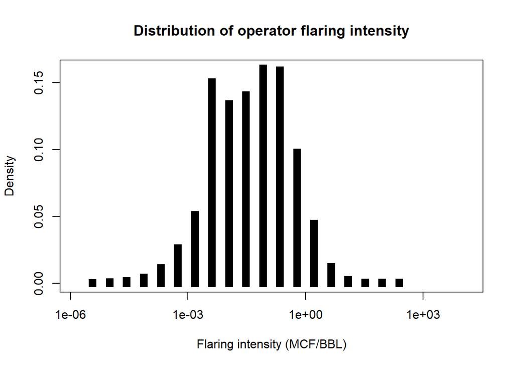

```r
OG_LEASE_CYCLE_DISP[, sum(flared_MCF) / sum(oil_BBL+cond_BBL), by=.(OPERATOR_NO, CYCLE_YEAR_MONTH)][
    CYCLE_YEAR_MONTH>201000,
    {"h_data"= hist(log(V1), plot=FALSE);
    plot(exp(h_data$mids), h_data$density, log='x', type='h', lwd=10, lend=2,
    main="Distribution of operator flaring intensity", xlab="Flaring intensity (MCF/BBL)", ylab="Density"); NULL}]
```

```r
# Lease, district numbers are unique
sum(duplicated(OG_LEASE_CYCLE_DISP, by=c("DISTRICT_NO", "LEASE_NO", "CYCLE_YEAR_MONTH")))
```

```
## [1] 0
```

```r
# Most OIL leases have at least some associated gas
summary(OG_LEASE_CYCLE_DISP[OIL_GAS_CODE=="O", sum(csgd_MCF), by=.(DISTRICT_NO, LEASE_NO)]$V1)
```

| Min. | 1st Qu. | Median | Mean | 3rd Qu. | Max. |
| --- | --- | --- | --- | --- | --- |
| 0 | 22 | 15999.5 | 329967.4 | 161698.8 | 1108801516 |

```r
# There is only casinghead gas in OIL leases
summary(OG_LEASE_CYCLE_DISP[OIL_GAS_CODE=="O", sum(gas_MCF), by=.(DISTRICT_NO, LEASE_NO)]$V1)
```

| Min. | 1st Qu. | Median | Mean | 3rd Qu. | Max. |
| --- | --- | --- | --- | --- | --- |
| 0 | 0 | 0 | 0 | 0 | 0 |

```r
# There is no casinghead gas disposition in GAS leases
summary(OG_LEASE_CYCLE_DISP[OIL_GAS_CODE=="G", sum(csgd_MCF), by=.(DISTRICT_NO, LEASE_NO)]$V1)
```

| Min. | 1st Qu. | Median | Mean | 3rd Qu. | Max. |
| --- | --- | --- | --- | --- | --- |
| 0 | 0 | 0 | 0 | 0 | 0 |

```r
# Condensate is only report in GAS leases
OG_LEASE_CYCLE_DISP[, sum(cond_BBL), by=.(DISTRICT_NO, LEASE_NO, OIL_GAS_CODE)][,
                            as.list(summary(V1)), by=OIL_GAS_CODE]
```

| OIL_GAS_CODE | Min. | 1st Qu. | Median | Mean | 3rd Qu. | Max. |
| --- | --- | --- | --- | --- | --- | --- |
| G | 0 | 0 | 219 | 14521.57 | 4208 | 6415990 |
| O | 0 | 0 | 0 | 0.00 | 0 | 0 |

```r
# Condensate accounts for a relatively small proportion of BOE
summary(OG_LEASE_CYCLE_DISP[gas_MCF > 0, cond_BBL / (gas_MCF/6)])
```

| Min. | 1st Qu. | Median | Mean | 3rd Qu. | Max. |
| --- | --- | --- | --- | --- | --- |
| 0 | 0 | 0 | 0.1711237 | 0 | 30282 |

```r
# GAS leases have no oil disposition:
summary(OG_LEASE_CYCLE_DISP[OIL_GAS_CODE=="G", sum(oil_BBL), by=.(DISTRICT_NO, LEASE_NO)]$V1)
```

| Min. | 1st Qu. | Median | Mean | 3rd Qu. | Max. |
| --- | --- | --- | --- | --- | --- |
| 0 | 0 | 0 | 0 | 0 | 0 |

```r
# and the proportion of gas flared in GAS leases is almost always zero:
OG_LEASE_CYCLE_DISP[OIL_GAS_CODE=="G", as.list(summary(flared_MCF/gas_MCF)),
                            keyby=substr(CYCLE_YEAR_MONTH,0,4)]
```

| substr | Min. | 1st Qu. | Median | Mean | 3rd Qu. | Max. | NA’s |
| --- | --- | --- | --- | --- | --- | --- | --- |
| 1993 | 0 | 0 | 0 | 0.0013512 | 0 | 1 | 5549 |
| 1994 | 0 | 0 | 0 | 0.0013503 | 0 | 1 | 5836 |
| 1995 | 0 | 0 | 0 | 0.0012539 | 0 | 1 | 6269 |
| 1996 | 0 | 0 | 0 | 0.0011009 | 0 | 1 | 6367 |
| 1997 | 0 | 0 | 0 | 0.0010025 | 0 | 1 | 6277 |
| 1998 | 0 | 0 | 0 | 0.0009960 | 0 | 1 | 6643 |
| 1999 | 0 | 0 | 0 | 0.0009902 | 0 | 1 | 7459 |
| 2000 | 0 | 0 | 0 | 0.0011159 | 0 | 1 | 6824 |
| 2001 | 0 | 0 | 0 | 0.0009813 | 0 | 1 | 6882 |
| 2002 | 0 | 0 | 0 | 0.0009084 | 0 | 1 | 6685 |
| 2003 | 0 | 0 | 0 | 0.0006418 | 0 | 1 | 6315 |
| 2004 | 0 | 0 | 0 | 0.0005336 | 0 | 1 | 6499 |
| 2005 | 0 | 0 | 0 | 0.0004862 | 0 | 1 | 5938 |
| 2006 | 0 | 0 | 0 | 0.0005190 | 0 | 1 | 6277 |
| 2007 | 0 | 0 | 0 | 0.0003453 | 0 | 1 | 7318 |
| 2008 | 0 | 0 | 0 | 0.0003492 | 0 | 1 | 7980 |
| 2009 | 0 | 0 | 0 | 0.0002869 | 0 | 1 | 7921 |
| 2010 | 0 | 0 | 0 | 0.0003352 | 0 | 1 | 8180 |
| 2011 | 0 | 0 | 0 | 0.0005367 | 0 | 1 | 9578 |
| 2012 | 0 | 0 | 0 | 0.0007166 | 0 | 1 | 11813 |
| 2013 | 0 | 0 | 0 | 0.0010990 | 0 | 1 | 13317 |
| 2014 | 0 | 0 | 0 | 0.0011242 | 0 | 1 | 13637 |
| 2015 | 0 | 0 | 0 | 0.0018627 | 0 | 1 | 13444 |
| 2016 | 0 | 0 | 0 | 0.0024418 | 0 | 1 | 14010 |
| 2017 | 0 | 0 | 0 | 0.0022671 | 0 | 1 | 14344 |
| 2018 | 0 | 0 | 0 | 0.0029644 | 0 | 1 | 14342 |
| 2019 | 0 | 0 | 0 | 0.0044560 | 0 | 1 | 16575 |
| 2020 | 0 | 0 | 0 | 0.0036454 | 0 | 1 | 16210 |
| 2021 | 0 | 0 | 0 | 0.0041010 | 0 | 1 | 2368 |

Identify leases of interest

```r
OG_IDS <- OG_LEASE_CYCLE_DISP[DISTRICT_NO %in% sprintf("%02d", c(1:4, 9:11))][,
                            .("start"= min(CYCLE_YEAR_MONTH), "expiration"= max(CYCLE_YEAR_MONTH), "N"= .N),
                            by=.(LEASE_NO, FIELD_NO, FIELD_NAME, DISTRICT_NO, OIL_GAS_CODE)]

# use the earliest well completion date to estimate start of lease lifetime
OG_IDS[OG_WELL[!is.na(area) & !is.na(depth) & !is.na(start), min(start), by=.(DISTRICT_NO, LEASE_NO)],
                on=c("DISTRICT_NO", "LEASE_NO"), "start":= pmin(V1, start)]
OG_IDS[, "lifetime":= .SD[, lapply(.(start, expiration), function(x) 12*trunc(x/100) + x %% 100)][, 1+V2-V1]]
```

Lease numbers can change over time. Where possible, back propagate new lease numbers to historic years

```r
# identify leases with changing identifiers and consolidate production from stacked wells
OG_IDS[OG_WELL[, if(uniqueN(LEASE_NO)>1) .SD, by=.("API"=fcoalesce(stacked, API_NO))][,
                .("API_NOs"=.(unique(API))), by=.(DISTRICT_NO, LEASE_NO)],
        on=c("DISTRICT_NO", "LEASE_NO"), "API_NOs":= API_NOs]
OG_IDS[, "size":= lengths(API_NOs)]

# propogate lease aliases
setorder(OG_IDS, -start)

# determine the most recent LEASE_NO and propogate backwards
OG_IDS[size==1,
    "alias":= {API=unlist(API_NOs); LEASE_NO[match(API, API)]}, by=DISTRICT_NO]
OG_IDS[size>1,
    "alias":= .(sapply(API_NOs, function(x) LEASE_NO[which(sapply(API_NOs, setequal, x))[1]])), by=.(size, DISTRICT_NO)]
OG_IDS[size>=1, "drop":= FALSE]
```

Drop certain leases

```r
# drop incomplete sets of leases as indicated by the well records
OG_IDS[OG_IDS[size>0, unlist(API_NOs), by=.(DISTRICT_NO, LEASE_NO)][, if(.N==1) .SD, by=V1],
        on=c("DISTRICT_NO", "LEASE_NO"), "drop":= TRUE]
# drop leases which don't map neatly to an alias (likely the number of member wells is different)
OG_IDS[!is.na(alias), "drop":= if(.N == 1) TRUE, by=.(DISTRICT_NO, alias)]
# drop leases where alias does not cover all well instances
OG_IDS[OG_IDS[drop==FALSE, unlist(API_NOs), by=.(DISTRICT_NO, LEASE_NO, alias)][, if(uniqueN(alias)>1) .SD, by=V1],
            on=c("DISTRICT_NO","LEASE_NO"), "drop":= TRUE]

# drop leases which have more missing data than entries
OG_IDS[!is.na(alias), "drop":= if((sum(N) / sum(lifetime)) < 0.5) TRUE, by=.(alias, DISTRICT_NO)]
OG_IDS[is.na(alias) & ((N / lifetime) < 0.5), "drop":= TRUE]

# drop leases which started operating too close to the end of the data period
OG_IDS[!is.na(alias), "drop":= if(min(start) > 201910) TRUE, by=.(alias, DISTRICT_NO)]
OG_IDS[is.na(alias) & (start > 201910), "drop":= TRUE]

# drop leases that stopped operating before 2010
OG_IDS[!is.na(alias), "drop":= if(max(expiration) < 201001) TRUE, by=.(alias, DISTRICT_NO)]
OG_IDS[is.na(alias) & (expiration < 201001), "drop":= TRUE]

# drop leases that changed from oil to gas (or vice versa)
OG_IDS[!is.na(alias), "drop":= if(uniqueN(OIL_GAS_CODE) > 1) TRUE, by=.(DISTRICT_NO, alias)]

# drop all occurences of dropped alias
OG_IDS[!is.na(alias), "drop":= if(sum(drop, na.rm=TRUE) > 1) TRUE, by=.(DISTRICT_NO, alias)]

# leases whose identifiers never changed are their own alias
OG_IDS[is.na(alias), "alias":= LEASE_NO]
```

Apply aliases to wells

```r
OG_WELL[OG_IDS[(is.na(drop) | drop==FALSE)], on=c("DISTRICT_NO", "LEASE_NO"), "alias":= alias]
```

## Combine with well (location) data

```r
# extract location from field names
OG_WELL[OG_IDS[grepl("spraberry", tolower(FIELD_NAME))], on=c("DISTRICT_NO","LEASE_NO"),
        "area":= replace(area, !is.na(lat), "Spraberry")]
OG_WELL[OG_IDS[grepl("midland", tolower(FIELD_NAME))], on=c("DISTRICT_NO","LEASE_NO"),
        "area":= replace(area, !is.na(lat), "Midland Basin")]
OG_WELL[OG_IDS[grepl("delaware", tolower(FIELD_NAME))], on=c("DISTRICT_NO","LEASE_NO"),
        "area":= replace(area, !is.na(lat), "Delaware Basin")]
OG_WELL[OG_IDS[grepl("eagle ford", tolower(FIELD_NAME))], on=c("DISTRICT_NO","LEASE_NO"),
        "area":= replace(area, !is.na(lat), "Eagle Ford")]

OG_IDS[ # aggregate by district & lease
        OG_WELL[!is.na(area) & !is.na(depth), .(mean(lat), mean(lon),
                names(sort(-table(area)))[1], names(sort(-table(COUNTY_NAME)))[1]), by=.(DISTRICT_NO, LEASE_NO)],
        on=c("DISTRICT_NO", "LEASE_NO"), c("lat", "lon", "area", "county"):= .(V1, V2, V3, V4)]
cat("Matched", OG_IDS[!is.na(lat), .N], "leases with wells & locations in Eagle Ford & Permian basins")
```

```
## Matched 59342 leases with wells & locations in Eagle Ford & Permian basins
```

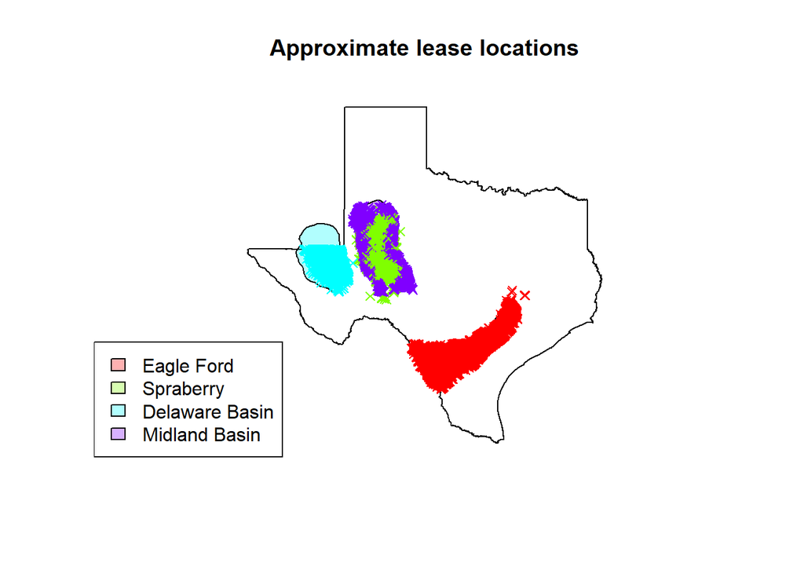

```r
# drop leases without location information
OG_IDS[is.na(lat), "drop":= TRUE]

plot(spatial_data$state$geometry, reset=FALSE, main="Approximate lease locations")
plot(spatial_data$areas$geometry, col=rainbow(4, alpha=0.3), add=TRUE)
legend("bottomleft", spatial_data$areas$Name, fill=rainbow(4, alpha=0.3))
OG_IDS[!is.na(area), plot(st_as_sf(.SD, coords=c("lon","lat"), crs=st_crs(spatial_data$area))$geometry,
                            col=rainbow(4)[factor(area, levels=spatial_data$areas$Name)], pch=4, add=TRUE)]
```

### Output complete well records

```r
fwrite(OG_WELL[!is.na(area) & !is.na(depth)], file="./processed/wells.csv")
rm(OG_WELL)
```

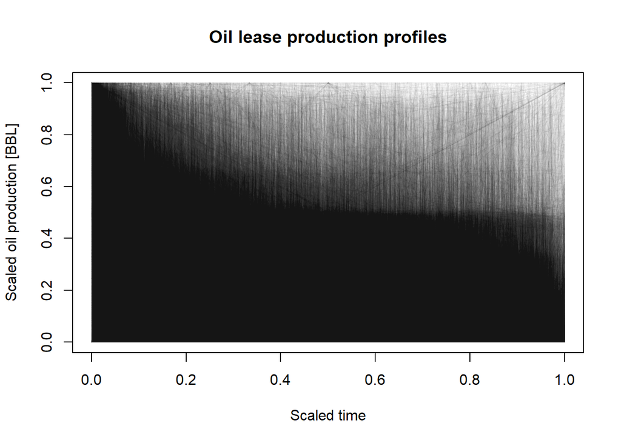

```r
plot(0, type="n", xlim=c(0, 1), ylim=c(0, 1),
    main="Oil lease production profiles", xlab="Scaled time", ylab="Scaled oil production [BBL]")
OG_LEASE_CYCLE_DISP[OG_IDS[(is.na(drop) | drop==FALSE) & (OIL_GAS_CODE=="O") & (expiration<201912)],
    on=c("LEASE_NO", "DISTRICT_NO", "FIELD_NO", "OIL_GAS_CODE")][,
        sum(total_oil_BBL), by=.(DISTRICT_NO, alias, CYCLE_YEAR_MONTH)][,
        {"time"= .SD[, .(12*trunc(CYCLE_YEAR_MONTH/100) + CYCLE_YEAR_MONTH %% 100)][, V1-min(V1)];
        lines(time/max(time), V1/max(V1), col=adjustcolor("black", 0.025)); NULL}, by=.(DISTRICT_NO, alias)]
```

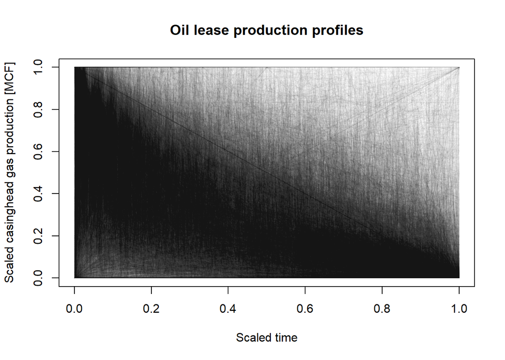

```r
plot(0, type="n", xlim=c(0, 1), ylim=c(0, 1),
    main="Oil lease production profiles", xlab="Scaled time", ylab="Scaled casinghead gas production [MCF]")
OG_LEASE_CYCLE_DISP[OG_IDS[(is.na(drop) | drop==FALSE) & (OIL_GAS_CODE=="O") & (expiration<201912)],
    on=c("LEASE_NO", "DISTRICT_NO", "FIELD_NO", "OIL_GAS_CODE")][,
        sum(total_MCF), by=.(DISTRICT_NO, alias, CYCLE_YEAR_MONTH)][,
        {"time"= .SD[, .(12*trunc(CYCLE_YEAR_MONTH/100) + CYCLE_YEAR_MONTH %% 100)][, V1-min(V1)];
        lines(time/max(time), V1/max(V1), col=adjustcolor("black", 0.025)); NULL}, by=.(DISTRICT_NO, alias)]
```

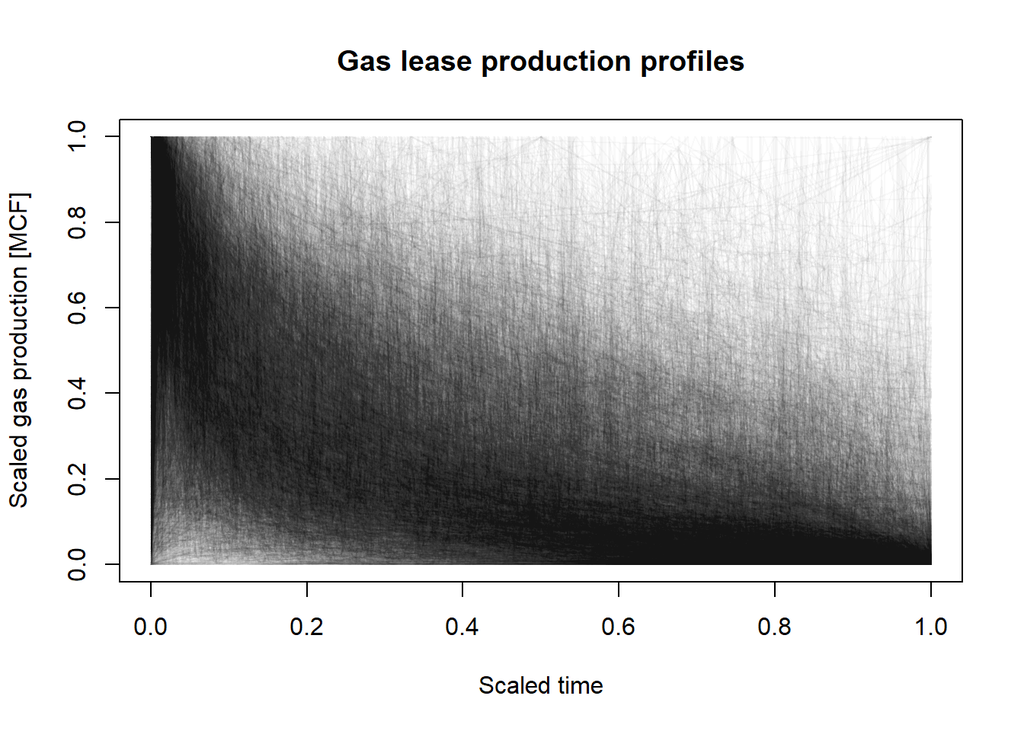

```r
plot(0, type="n", xlim=c(0, 1), ylim=c(0, 1),
    main="Gas lease production profiles", xlab="Scaled time", ylab="Scaled gas production [MCF]")
OG_LEASE_CYCLE_DISP[OG_IDS[(is.na(drop) | drop==FALSE) & (OIL_GAS_CODE=="G") & (expiration<201912)],
    on=c("LEASE_NO", "DISTRICT_NO", "FIELD_NO", "OIL_GAS_CODE")][,
        sum(total_MCF), by=.(DISTRICT_NO, alias, CYCLE_YEAR_MONTH)][,
        {"time"= .SD[, .(12*trunc(CYCLE_YEAR_MONTH/100) + CYCLE_YEAR_MONTH %% 100)][, V1-min(V1)];
        lines(time/max(time), V1/max(V1), col=adjustcolor("black", 0.025)); NULL}, by=.(DISTRICT_NO, alias)]
```

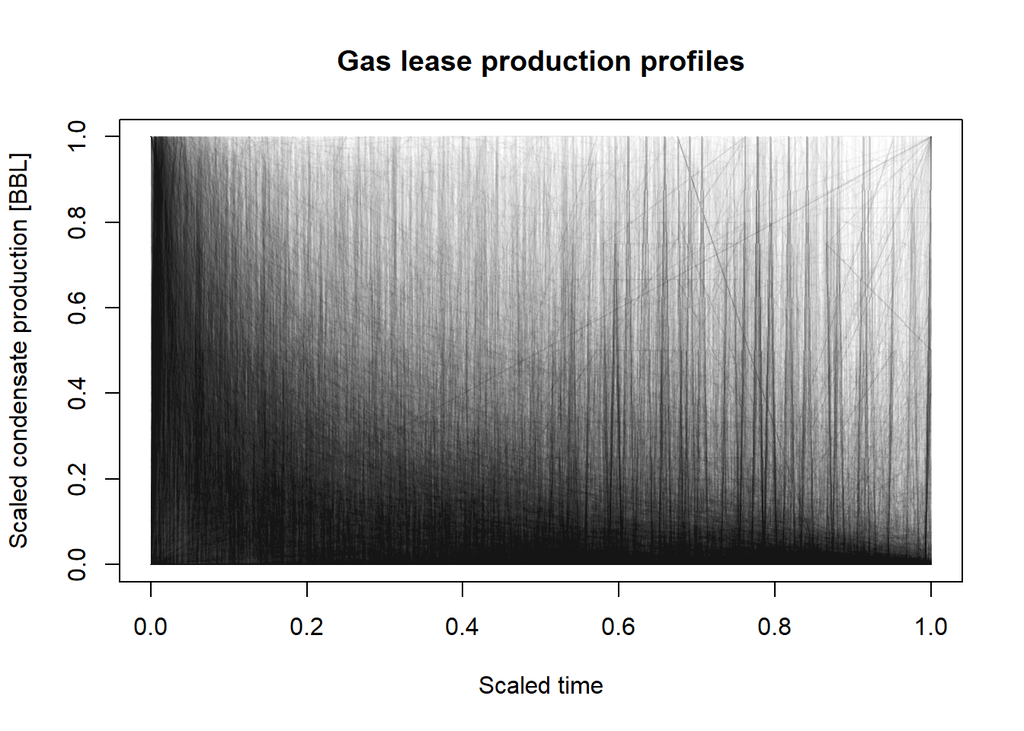

```r
plot(0, type="n", xlim=c(0, 1), ylim=c(0, 1),
    main="Gas lease production profiles", xlab="Scaled time", ylab="Scaled condensate production [BBL]")
OG_LEASE_CYCLE_DISP[OG_IDS[(is.na(drop) | drop==FALSE) & (OIL_GAS_CODE=="G") & (expiration<201912)],
    on=c("LEASE_NO", "DISTRICT_NO", "FIELD_NO", "OIL_GAS_CODE")][,
        sum(cond_BBL), by=.(DISTRICT_NO, alias, CYCLE_YEAR_MONTH)][,
        {"time"= .SD[, .(12*trunc(CYCLE_YEAR_MONTH/100) + CYCLE_YEAR_MONTH %% 100)][, V1-min(V1)];
        lines(time/max(time), V1/max(V1), col=adjustcolor("black", 0.025)); NULL}, by=.(DISTRICT_NO, alias)]
```

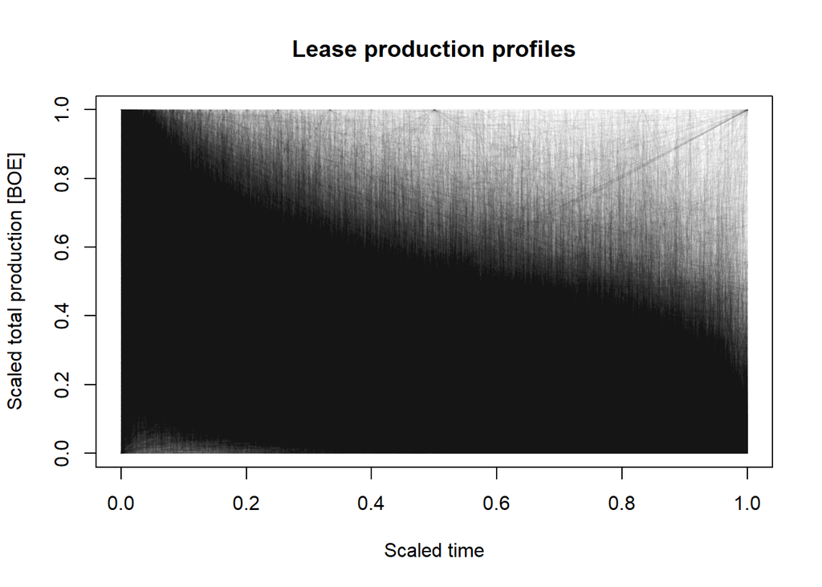

```r
plot(0, type="n", xlim=c(0, 1), ylim=c(0, 1),
    main="Lease production profiles", xlab="Scaled time", ylab="Scaled total production [BOE]")
OG_LEASE_CYCLE_DISP[OG_IDS[(is.na(drop) | drop==FALSE) & (expiration<201912)],
    on=c("LEASE_NO", "DISTRICT_NO", "FIELD_NO", "OIL_GAS_CODE")][,
        sum(total_BOE), by=.(DISTRICT_NO, alias, CYCLE_YEAR_MONTH)][,
        {"time"= .SD[, .(12*trunc(CYCLE_YEAR_MONTH/100) + CYCLE_YEAR_MONTH %% 100)][, V1-min(V1)];
        lines(time/max(time), V1/max(V1), col=adjustcolor("black", 0.025)); NULL}, by=.(DISTRICT_NO, alias)]
```

## Summarize lease production

Average production characteristics of leases from 2010 onward

```r
OG_LEASE_AVG <- OG_LEASE_CYCLE_DISP[OG_IDS[is.na(drop) | drop==FALSE],
                                    on=c("LEASE_NO", "DISTRICT_NO", "FIELD_NO", "OIL_GAS_CODE")][
                                    order(CYCLE_YEAR_MONTH),
                                    c("OPERATOR_NO"= ifelse(uniqueN(OPERATOR_NO)==1, first(OPERATOR_NO), NA_integer_),
                                    "start"= min(start), "expiration"= max(expiration),
                                    "area"= first(area), "county"= first(county), "lat"= first(lat), "lon"= first(lon),
                                    # "Estimated Ultimate Recovery" from emprical distribution
                                    .SD[, sum(total_BOE), keyby=CYCLE_YEAR_MONTH][CYCLE_YEAR_MONTH>=max(start)][
                                    between(CYCLE_YEAR_MONTH, CYCLE_YEAR_MONTH[which.max(V1)], 201912),
                                        #   time of peak production
                                        c("t_i"= CYCLE_YEAR_MONTH[1],
                                        #   initial (peak) Production and decline
                                        "q_i"= V1[1],
                                        "qdel_i"= mean((V1[1] - V1[2:4]) / 1:3, na.rm=TRUE),
                                        "q_fit"= sum(V1))],
                                    #   total Quantity produced prior to the time window
                                    .SD[CYCLE_YEAR_MONTH<201001,
                                        c("qcum_0_BBL"= sum(total_oil_BBL+cond_BBL),
                                          "qcum_0_MCF"= sum(total_MCF))] +
                                    # back-cast constant production before start of reporting
                                        diff(sapply(.(min(start), 199301),
                                                function(x) 12*trunc(x/100) + x %% 100)) *
                                            .SD[CYCLE_YEAR_MONTH==199301,
                                            c(sum(total_oil_BBL+cond_BBL), sum(total_MCF))],
                                    #   total Quantity produced during time window
                                    .SD[between(CYCLE_YEAR_MONTH, 201001, 201912),
                                        c("qcum_i_BBL"= sum(total_oil_BBL+cond_BBL),
                                          "qcum_i_MCF"= sum(total_MCF))],
                                    lapply(.SD[between(CYCLE_YEAR_MONTH, 201001, 201912),
                                                c("oil_BBL","cond_BBL","gas_MCF","csgd_MCF",
                                                "total_BOE", "total_oil_BBL","total_MCF","flared_MCF",
                                                # fraction of oil transported by pipeline, rail, & truck
                                                sprintf("LEASE_OIL_DISPCD%02d_VOL", 0:2))] /
                                                uniqueN(CYCLE_YEAR_MONTH[between(CYCLE_YEAR_MONTH, 201001, 201912)]),
                                            sum, na.rm=TRUE)),
                                    by=.("LEASE_NO"= alias, DISTRICT_NO, OIL_GAS_CODE)]

setnames(OG_LEASE_AVG, c("oil_BBL","cond_BBL","gas_MCF","csgd_MCF","total_oil_BBL","total_MCF","flared_MCF"),
                    c("oil_avg","cond_avg","gas_avg","csgd_avg","total_oil_avg","total_MCF_avg","flared_MCF_avg"))

rm(OG_IDS)
rm(OG_LEASE_CYCLE_DISP)
head(OG_LEASE_AVG)
```

```
##    LEASE_NO DISTRICT_NO OIL_GAS_CODE OPERATOR_NO  start expiration       area
## 1:   143921          01            G       15988 199301     202102 Eagle Ford
## 2:   144062          01            G          NA 199301     202102 Eagle Ford
## 3:   144512          02            G        4399 199301     202102 Eagle Ford
## 4:   144439          04            G          NA 199301     202102 Eagle Ford
## 5:   144319          04            G          NA 199301     202102 Eagle Ford
## 6:   143896          04            G          NA 199301     202102 Eagle Ford
##      county      lat       lon    t_i      q_i   qdel_i    q_fit qcum_0_BBL
## 1: LA SALLE 28.21581 -99.25137 199303 3735.333 334.4907 143460.5          0
## 2: MCMULLEN 28.41724 -98.48801 199312 4882.167 368.7870 250211.8      37195
## 3:   KARNES 28.75412 -97.90864 199407 3110.833 192.1759 249845.3       2261
## 4:     WEBB 28.10903 -99.52585 199301 4472.167 523.5278 120551.3       3262
## 5:     WEBB 27.94381 -99.66670 199303 1919.333 396.5370  56997.0        101
## 6:     WEBB 28.10029 -99.51510 199302 5267.333 307.1944 125398.7       5320
##    qcum_0_MCF qcum_i_BBL qcum_i_MCF oil_avg cond_avg   gas_avg csgd_avg
```

[output cut: 20 more lines]

Calculate how oil leaves the lease (disposition)

```r
OG_LEASE_AVG[OIL_GAS_CODE=="O", sprintf("%s_frac", c("pipe","rail","truck")):= .SD / oil_avg,
                        .SDcols=sprintf("LEASE_OIL_DISPCD%02d_VOL", 0:2)]

# drop unused columns
OG_LEASE_AVG[, sprintf("LEASE_OIL_DISPCD%02d_VOL", 0:2) := NULL]

cat(uniqueN(OG_LEASE_AVG, by=c("DISTRICT_NO", "LEASE_NO")), "leases have data after 2010", "\n")
```

```
## 35752 leases have data after 2010
```

## Formulate decline curves

Typical well production in areas of interest

```r
decline_params <- read_xlsx("./data/decline_curves.xlsx", sheet="decline parameters", skip=2, n_max=195)
setDT(decline_params)

setnames(decline_params, gsub("\r\n", " ", names(decline_params)))
setnames(decline_params, gsub("  ", " ", names(decline_params)))

decline_params[, "area":= gsub("(.*)-.*", "\\1", Play)]
decline_params[area=="Bonespring", "area":= "Delaware Basin"]
decline_params[area=="Wolfcamp", area:= ifelse(County %in% c("Culberson","Pecos","Reeves","Ward","Winkler","Loving"),
                                                "Delaware Basin", "Midland Basin")]
decline_params[State!="TX", "area":= NA]
decline_params[, "county":= toupper(County)]
decline_params[county=="DEWITT", county:= "DE WITT"]

decline_params[, "ratio":= (`Estimated ultimate recovery of dry natural gas (MMcf/well)` * 1000) /
                            (`Initial dry natural gas production rate (Mcf/d)` * 30.4)]
decline_params[, "scaled_ratio":= ratio * `Initial decline rate`]
```

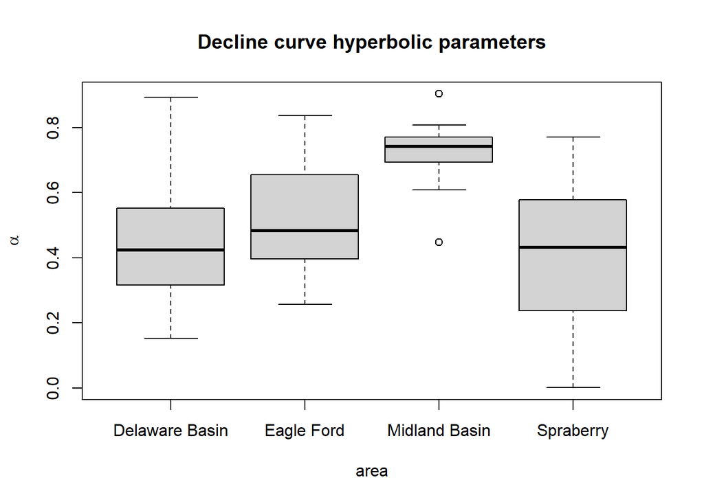

```r
decline_params[area %in% c("Eagle Ford", "Spraberry", "Delaware Basin", "Midland Basin"),
            {boxplot(`Hyperbolic parameter`~area, main="Decline curve hyperbolic parameters",
                    ylab=expression(alpha)); NULL}]
```

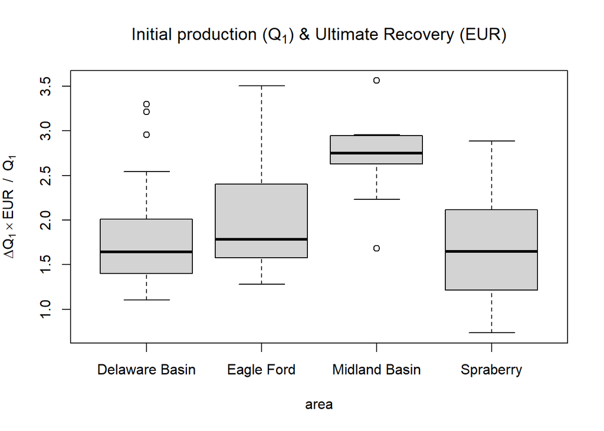

```r
decline_params[area %in% c("Eagle Ford", "Spraberry", "Delaware Basin", "Midland Basin"),
            {boxplot(scaled_ratio~area, main=expression("Initial production (" * Q[1] * ") & Ultimate Recovery (EUR)"),
                    ylab=expression(Delta * Q[1] %*% "EUR" ~~ "/" ~~ Q[1])); NULL}]
```

```r
fwrite(decline_params[area %in% c("Eagle Ford", "Spraberry", "Delaware Basin", "Midland Basin")],
        "./processed/decline_params.csv")
```

Store decline functions as strings to evaluate given parameters

```r
# offset from peak time to last data point (after which decline function is used)
OG_LEASE_AVG[, "m_shift":= .SD[, lapply(.(t_i, pmin(expiration, 201912)),
                            function(x) 12*trunc(x/100) + x %% 100)][, V2-V1]]
OG_LEASE_AVG[m_shift<0, "m_shift":= 0]

# calibrate hyperbolic parameter
OG_LEASE_AVG[!is.na(qdel_i) & ((total_oil_avg + cond_avg + total_MCF_avg/6)>0) & (q_fit>0),
        "param":= optimize(function(x) (q_fit - sum(sapply(seq(m_shift+1) - 1,
                                                    function(m) q_i / (1 + (m * x * (qdel_i / q_i)))^(1/x))))^2,
                    c(0, 1))$minimum, by=.(DISTRICT_NO, LEASE_NO)]

OG_LEASE_AVG[!is.na(q_i) & !is.na(qdel_i) & ((total_oil_avg + cond_avg + total_MCF_avg/6)>0),
            "decline_fun":= sprintf("function(dqi, len, param)
                                        sum(sapply(%1$d + seq(len) - 1, function(m)
                                            %2$f / (1 + (m * param * (dqi / %2$f)))^(1/param)))", m_shift, q_i)]

# clean up formatting
OG_LEASE_AVG[, "decline_fun":= gsub("\n|  ", "", decline_fun)]
```

## Determine distances to infrastructure

Distance from leases to infrastructure is used as an ordering variable for costs

```r
cat("CRS ok:", st_crs(spatial_data$gas_plants) == st_crs(spatial_data$crude_pipelines), "\n")
```

```
## CRS ok: TRUE
```

```r
OG_LEASE_sf <- st_as_sf(OG_LEASE_AVG[!is.na(area)], coords=c("lon","lat"), crs=st_crs(spatial_data$gas_plants))

# measure distance to nearest facilities
# process in 10 chunks to avoid memory issues
print("Measuring distances to gas processing facilities & crude pipelines...")
```

```
## [1] "Measuring distances to gas processing facilities & crude pipelines..."
```

```r
OG_LEASE_sf[, c("gas_cap", "gas_dist", "crude_dist")] <- NA
for (chunk in split(1:nrow(OG_LEASE_sf), sort(rep_len(1:10, nrow(OG_LEASE_sf))))) {
    # capacity of plants weighted by inverse square of distance
    OG_LEASE_sf$gas_cap[chunk] <- apply(st_distance(spatial_data$gas_plants, OG_LEASE_sf[chunk,]), 2,
                                        function(x) weighted.mean(spatial_data$gas_plants$Cap_MMcfd, 1/x^2))
    # distance to nearest gas processing facility
    OG_LEASE_sf$gas_dist[chunk] <- apply(st_distance(spatial_data$gas_plants, OG_LEASE_sf[chunk,]), 2, min)

    # distance to nearest major crude oil pipeline
    OG_LEASE_sf$crude_dist[chunk] <- apply(st_distance(spatial_data$crude_pipelines, OG_LEASE_sf[chunk,]), 2, min)
    cat(100*max(chunk)/nrow(OG_LEASE_sf), "%   ")
}
```

```
## 10.00224 %   20.00448 %   30.00392 %   40.00336 %   50.0028 %   60.00224 %   70.00168 %   80.00112 %   90.00056 %   100 %
```

Merge distance data with full lease record

```r
st_geometry(OG_LEASE_sf) <- NULL
setDT(OG_LEASE_sf)
OG_LEASE_AVG[OG_LEASE_sf, on=c("DISTRICT_NO", "LEASE_NO"),
                c("gas_cap", "gas_dist", "crude_dist"):= .(gas_cap, gas_dist, crude_dist)]
rm(OG_LEASE_sf)
```

### Output complete lease records

```r
fwrite(OG_LEASE_AVG[!is.na(area) & !(cond_avg+gas_avg+oil_avg==0) & !(is.na(qdel_i) | is.infinite(qdel_i))],
        file="./processed/leases_emp.csv")
```